# Data_607_Project_4_Document_Classification

Enid Roman

2022-11-19

#### It can be useful to be able to classify new “test” documents using already classified “training” documents. A common example is using a corpus of labeled spam and ham (non-spam) e-mails to predict whether or not a new document is spam.

#### For this project, we start with a spam/ham dataset, then predict the class of new documents (either withheld from the training dataset or from another source such as your own spam folder). One example corpus: https://spamassassin.apache.org/old/publiccorpus/

### **LOAD REQUIRED LIBRARIES**

#### Install & load necessary libraries.

#### TM is R’s text mining package, which provides several functions for text handling, processing and management. The package uses the concept of a ‘corpus’ which is a collection of text documents to operate upon. Text can be stored either in-memory in R via a Volatile Corpus or on an external data store such as a database via a Permanent Corpus.

#### Other packages are supplementary packages that are used for reading lines from file, plotting, preparing word clouds, N-Gram generation, etc.

```r
#install.packages('tm')
library(tidyverse)
```

```r
library(tidyr)
library(dplyr)
library(purrr)
library(stringr)
library(stringi)
library(ggplot2)
library(readr)
library(stats)
library(magrittr)
library(R.utils)
#install.packages("kableExtra")
library(kableExtra)
library(tm)
library(wordcloud)
library(topicmodels)
library(SnowballC)
library(e1071)
library(data.table)
#install.packages('quanteda')
library(quanteda)
#install.packages('naivebayes')
library(naivebayes)
```

### **DATA COLLECTION**

#### Obtained the spam and ham data from Spam Assassin Appache site: https://spamassassin.apache.org/old/publiccorpus/. Went to Public Corpus folder.

#### Downloaded spam and ham data to use for the document classification exercise. For spam, I downloaded 20030228_spam.tar.bz2 and for ham folder I downloaded 20030228_easy_ham_2.tar.bz2.

#### Unzipped both folders using 7-zip file manager.

#### Opened both files in Notepad ++ to explore spam and ham emails.

```r
# Load the spam and ham data into R from my folder in my computer. Had trouble creating the corpus when I used the url.

#url_spam <- "https://spamassassin.apache.org/old/publiccorpus/20030228_spam.tar.bz2"
#url_ham <- "https://spamassassin.apache.org/old/publiccorpus/20030228_easy_ham_2.tar.bz2"

pathName_spam <- "C:\\Users\\enidr\\OneDrive\\Documents\\CUNY SPS DATA 607\\Project 4\\spam"
file_name_spam <- list.files(pathName_spam)

pathName_ham <- "C:\\Users\\enidr\\OneDrive\\Documents\\CUNY SPS DATA 607\\Project 4\\easy_ham_2"
file_name_ham <- list.files(pathName_ham)
```

#### Got the first number of rows to test if I have the right type of data.

```r
head(file_name_spam)
```

```
## [1] "00001.7848dde101aa985090474a91ec93fcf0"
## [2] "00002.d94f1b97e48ed3b553b3508d116e6a09"
## [3] "00003.2ee33bc6eacdb11f38d052c44819ba6c"
## [4] "00004.eac8de8d759b7e74154f142194282724"
## [5] "00005.57696a39d7d84318ce497886896bf90d"
## [6] "00006.5ab5620d3d7c6c0db76234556a16f6c1"
```

```r
head(file_name_ham)
```

```
## [1] "00001.1a31cc283af0060967a233d26548a6ce"
## [2] "00002.5a587ae61666c5aa097c8e866aedcc59"
## [3] "00003.19be8acd739ad589cd00d8425bac7115"
## [4] "00004.b2ed6c3c62bbdfab7683d60e214d1445"
## [5] "00005.07b9d4aa9e6c596440295a5170111392"
## [6] "00006.654c4ec7c059531accf388a807064363"
```

#### Got the length 501 for spam emails and 1401 for non spam (ham) emails

```r
length_spam <- length(file_name_spam)
length_spam
```

```
## [1] 501
```

```r
length_ham <- length(file_name_ham)
length_ham
```

```
## [1] 1401
```

#### Obtained the file size, line size, and file words for both spam and ham files.

```r
file_size <- format(object.size(file_name_spam), units = "Kb")
file_num_lines <- length(file_name_spam)
file_words <- sum(stri_count_words(file_name_spam))
cat (" File Size: ", file_size, " Line Size: ", file_num_lines, " File Words: ", file_words)
```

```
##  File Size:  50.9 Kb  Line Size:  501  File Words:  694
```

```r
file_size <- format(object.size(file_name_ham), units = "Kb")
file_num_lines <- length(file_name_ham)
file_words <- sum(stri_count_words(file_name_ham))
cat (" File Size: ", file_size, " Line Size: ", file_num_lines, " File Words: ", file_words)
```

```
##  File Size:  142.3 Kb  Line Size:  1401  File Words:  1912
```

#### Removed the .cmds files from all the files.

```r
file_name_spam <- file_name_spam[which(file_name_spam!="cmds")]
file_name_ham <- file_name_ham[which(file_name_ham!="cmds")]
```

#### Used ‘list.files’ on our ‘spam_folder’ object which produces a character vector of the names of files.

```r
spam_email = list.files(path = "spam_file", full.names = TRUE)
ham_email = list.files(path = "ham_file",full.names = TRUE)
```

### **Processing Textual Data - Corpus Creation**

#### We need to create a collection of documents (technically referred to as a Corpus) in the R environment. This basically involves loading the files created in the TextMining folder into a Corpus object. The tm package provides the Corpus() function to do this.

```r
# spam folder files

spam_corpus <- pathName_spam %>%
  paste(., list.files(.), sep = "/") %>%
  lapply(readLines) %>%
  VectorSource() %>%
  VCorpus()
spam_corpus
```

```
## <<VCorpus>>
## Metadata:  corpus specific: 0, document level (indexed): 0
## Content:  documents: 501
```

```r
# ham folder files

ham_corpus <- pathName_ham %>%
  paste(., list.files(.), sep = "/") %>%
  lapply(readLines) %>%
  VectorSource() %>%
  VCorpus()

ham_corpus
```

```
## <<VCorpus>>
## Metadata:  corpus specific: 0, document level (indexed): 0
## Content:  documents: 1401
```

### **Corpus Cleaning**

##### In terms of cleaning the corpus for each folder we will use the tm package and follow below steps;

##### Remove the numbers and punctuations

##### Remove stopwords such as to, from, and, the etc…

##### Reduce the terms to their stem.

```r
# spam emails

spam_corpus <- spam_corpus %>%
  tm_map(removeNumbers) %>%
  tm_map(removePunctuation) %>%
  tm_map(removeWords, stopwords()) %>%
  tm_map(stripWhitespace) %>%
  tm_map(stemDocument)
spam_corpus
```

```
## <<VCorpus>>
## Metadata:  corpus specific: 0, document level (indexed): 0
## Content:  documents: 501
```

```r
# ham emails

ham_corpus <- ham_corpus %>%
  tm_map(removeNumbers) %>%
  tm_map(removePunctuation) %>%
  tm_map(removeWords, stopwords()) %>%
  tm_map(stripWhitespace) %>%
  tm_map(stemDocument)
ham_corpus
```

```
## <<VCorpus>>
## Metadata:  corpus specific: 0, document level (indexed): 0
## Content:  documents: 1401
```

#### Combined both spam and non spam (ham) emails.

```r
spam_or_ham_corpus <- c(spam_corpus, ham_corpus)
```

### **Building a Term Document Matrix**

```r
tdm <- DocumentTermMatrix(spam_or_ham_corpus)
tdm
```

```
## <<DocumentTermMatrix (documents: 1902, terms: 55131)>>
## Non-/sparse entries: 345402/104513760
## Sparsity           : 100%
## Maximal term length: 461
## Weighting          : term frequency (tf)
```

### **Creating Word Cloud with Header Text**

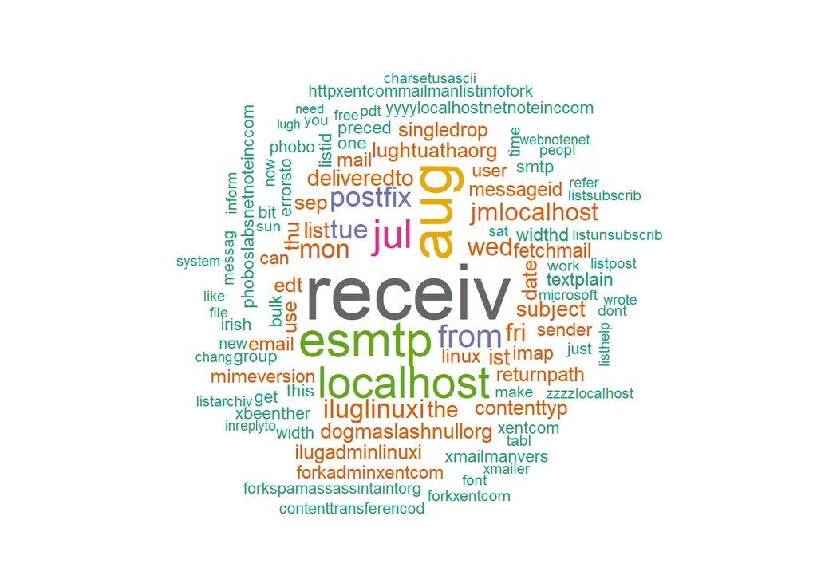

```r
wordcloud(spam_or_ham_corpus, max.words = 100, random.order = FALSE, rot.per=0.15, min.freq=5, colors = brewer.pal(8, "Dark2"))
```

### **MODEL DEVELOPMENT**

#### A classification such as Naive Bayes classifier is being used to find out the presence of certain features (words) in a defined class to predict if the email is spam or ham.

### **Data Preperation for Model Development**

### **Creating Dataframe**

```r
df_spam <- as.data.frame(unlist(spam_corpus), stringsAsFactors = FALSE)
df_spam$type <- "ham"
colnames(df_spam)=c("text", "email")

df_ham <- as.data.frame(unlist(ham_corpus), stringsAsFactors = FALSE)
df_ham$type <- "spam"
colnames(df_ham)=c("text", "email")

df_spam_or_ham <- rbind(df_spam, df_ham)

kable(head(df_spam_or_ham))
```

| text | email |
| --- | --- |
| From amailbotwebd Thu Aug | ham |
| ReturnPath amailbotwebd | ham |
| DeliveredTo zzzzlocalhostspamassassintaintorg | ham |
| Receiv localhost localhost | ham |
| phoboslabsspamassassintaintorg Postfix ESMTP id BC | ham |
| zzzzlocalhost Thu Aug EDT | ham |

#### **Prepare Test and Train Data**

#### **Splitting Test and Train Data**

```r
sample_size <- floor(0.80 * nrow(df_spam_or_ham)) # selecting sample size of 80% of the data for training.

set.seed(123)
train <- sample(seq_len(nrow(df_spam_or_ham)), size = sample_size)

train_spam_or_ham <- df_spam_or_ham[train, ]
test_spam_or_ham <- df_spam_or_ham[-train, ]

head(train_spam_or_ham)
```

```
##                                      text email
## 182735                                122  spam
## 188942     httpxentcommailmanlistinfofork  spam
## 134058                 httpthinkgeekcomsf  spam
## 124022                                     spam
## 160997                                     spam
## 226318 mv dcaeadfcaefeebb dcaeadfcaefeebb  spam
```

```r
head(test_spam_or_ham)
```

```
##                                                  text email
## 2                             ReturnPath amailbotwebd   ham
## 5  phoboslabsspamassassintaintorg Postfix ESMTP id BC   ham
## 6                           zzzzlocalhost Thu Aug EDT   ham
## 14        Receiv rsmtpkoreacom ddit Microsoft SMTPSVC   ham
## 15                                            Sat Aug   ham
## 25                                           HTMLHEAD   ham
```

#### Create and Clean Corpus and Create Term Document Matrix for Training and Test Data.

```r
# corpus creation
train_corpus <- Corpus (VectorSource(train_spam_or_ham$text)) # corpus training data
test_corpus <- Corpus(VectorSource(test_spam_or_ham$text)) # corpus test data

# corpus cleaning
train_corpus <- train_corpus %>%
  tm_map(removeNumbers) %>%
  tm_map(removePunctuation) %>%
  tm_map(removeWords, stopwords()) %>%
  tm_map(stripWhitespace)
test_corpus <- test_corpus %>%
  tm_map(removeNumbers) %>%
  tm_map(removePunctuation) %>%
  tm_map(removeWords, stopwords()) %>%
  tm_map(stripWhitespace)
train_tdm <- DocumentTermMatrix(train_corpus)
test_tdm <- DocumentTermMatrix(test_corpus)

train_tdm
```

```
## <<DocumentTermMatrix (documents: 181536, terms: 47685)>>
## Non-/sparse entries: 444327/8656099833
## Sparsity           : 100%
## Maximal term length: 298
## Weighting          : term frequency (tf)
```

```r
test_tdm
```

```
## <<DocumentTermMatrix (documents: 45384, terms: 19722)>>
## Non-/sparse entries: 111123/894952125
## Sparsity           : 100%
## Maximal term length: 117
## Weighting          : term frequency (tf)
```

```r
train_corpus
```

```
## <<SimpleCorpus>>
## Metadata:  corpus specific: 1, document level (indexed): 0
## Content:  documents: 181536
```

```r
test_corpus
```

```
## <<SimpleCorpus>>
## Metadata:  corpus specific: 1, document level (indexed): 0
## Content:  documents: 45384
```

#### Separate training data to spam and ham.

```r
spam <- subset(train_spam_or_ham, email == "spam")
ham <- subset(train_spam_or_ham, email == "ham")
```

#### If we run all the observation in my data, R doesnt have enough memory to execute it at the moment. So, I am going to narrow down the observations by selecting words that uses at least 50 times in the training document.

```r
fifty_times_words<- findFreqTerms(train_tdm, 50)
length(fifty_times_words)
```

```
## [1] 1252
```

#### Create a classifier for each email.

```r
train_tdm_2<- DocumentTermMatrix(train_corpus, control=list(dictionary = fifty_times_words))

test_tdm_2<- DocumentTermMatrix(test_corpus, control=list(dictionary = fifty_times_words))
```

#### Create a classifier for each email.

```r
# This is required in order to set the classifier for naiveBayes

class(train_tdm_2)
```

```
## [1] "DocumentTermMatrix"    "simple_triplet_matrix"
```

#### Train the model.

```r
train_tdm_3 <- as.matrix(train_tdm_2)
train_tdm_3 <- as.data.frame(train_tdm_3)
class(train_tdm_3)
```

```
## [1] "data.frame"
```

```r
classifier <- naiveBayes(train_tdm_3, factor(train_spam_or_ham$email))
```

```r
class(classifier)
```

```
## [1] "naiveBayes"
```

#### Test the model.

```r
class(test_tdm_2)
```

```
## [1] "DocumentTermMatrix"    "simple_triplet_matrix"
```

```r
test_tdm_3 <- as.matrix(test_tdm_2)
test_tdm_3 <- as.data.frame(test_tdm_3)
class(test_tdm_3)
```

```
## [1] "data.frame"
```

### **PREDICTION**

#### We can use the predict function to test the model on new data. ” test_pred <- predict(classifier, newdata=test_tdm_3)“.

```r
test_pred <- predict(classifier, newdata=test_tdm_3)
```

```r
table(predicted=test_pred,actual=test_tdm_3[,1])
```

```
##          actual
## predicted     0     1
##      ham  41269   415
##      spam  3700     0
```

### **CONCLUSION**

#### I first ran into problem when I loaded the url from the website provided by the professor. Codes were running well until I started to create the Corpus. I then had to load the file from my computer which workded out very well with all the codes. Since most of the codes took longer to run I had to change the class type to make the classifier work.